# Fox Lab Intro to R 2023

Alicia Vallorani

2023-09-21

# Overview

This document is designed to provide an introduction to using R for basic data manipulation, visualization and analyses. This document assumes the user knows how to set-up R. More information about setting-up are can be found [here](https://github.com/auv27/intro_to_r/tree/main/getting_started).

This document is known as an RMarkdown. RMarkdown is a useful tool for integrating text and code. It is also possible to use basic r scripts to conduct any processes shown here.

# Loading packages

The code I am including here will automatically install and load packages that are needed for the script to run. Some people don’t like this and prefer the choice of what to install so just be cognizant. If you do not want to install everything, you can use `install.packages()` to install individual packages and `library()` to load individual packages.

In the call below, I load [tidyverse](https://www.tidyverse.org/) which is a package containing a family of packages. All Tidyverse packages use a common “grammar” for coding and I will use this throughout the script. It is also possible to do many of the same processes I show using base R or other packages, but I find Tidyverse the most useful for consistency. For this script, I am using the following tidyverse packages: stringr, tidyr, dplyr, ggplot2. I will also use the psych, Hmisc, GGally and viridis packages which are not a part of the Tidyverse but work within the Tidyverse grammar.

```r
if (!("pacman" %in% installed.packages()[,])) {
    install.packages("pacman")
  }
pacman::p_load(tidyverse, psych, Hmisc, GGally, viridis)
```

# Setting up an environment

There are a few different ways to set-up an environment for manipulating, analyzing and visualizing data in R. Some people like to use [projects](https://bookdown.org/daniel_dauber_io/r4np_book/starting-your-r-projects.html). Others prefer to [set a working directory](https://finnstats.com/2021/12/30/get-and-set-working-directory-setwd-getwd-in-r/) using `setwd()`.

I prefer to use relative paths because of the flexibility it affords, but there is no right or wrong way to set-up an environment. Just choose what works best for you.

```r
# Set home path - level that contains all needed folders
## You would need to adjust this path to match the location you want
home_path <- "/Users/aliciavallorani/Library/CloudStorage/Box-Box/Standard Codes/intro_to_r"

# Set data path
data_path <- file.path(home_path,"/tutorial_data/candy_data.csv", fsep = "")
```

I personally always like to preset my visualization environment by sourcing in a visualization theme for all my plots.

```r
source("/Users/aliciavallorani/Library/CloudStorage/Box-Box/Standard Codes/visualization_tools/basic_theme.R")
theme_set(basic_theme)
```

# Reading in data

Today we only have one data file to read in which is relatively straightforward. Reading in multiple files (such as reading in separate behavioral task files for every individual participant) is a more advanced concept that I am happy to discuss individually or in a future tutorial. Merging 2 or more data sets is also a concept I’m happy to discuss individually or in a future tutorial.

The data for today are drawn from the 539 article [“The Ultimate Halloween Candy Power Ranking”](https://fivethirtyeight.com/videos/the-ultimate-halloween-candy-power-ranking/). You can learn more about the data set [here](https://github.com/fivethirtyeight/data/tree/master/candy-power-ranking).

```r
# Read-in the data
candy_df <- read.csv(data_path)
```

**Variable definitions as provided by 539**

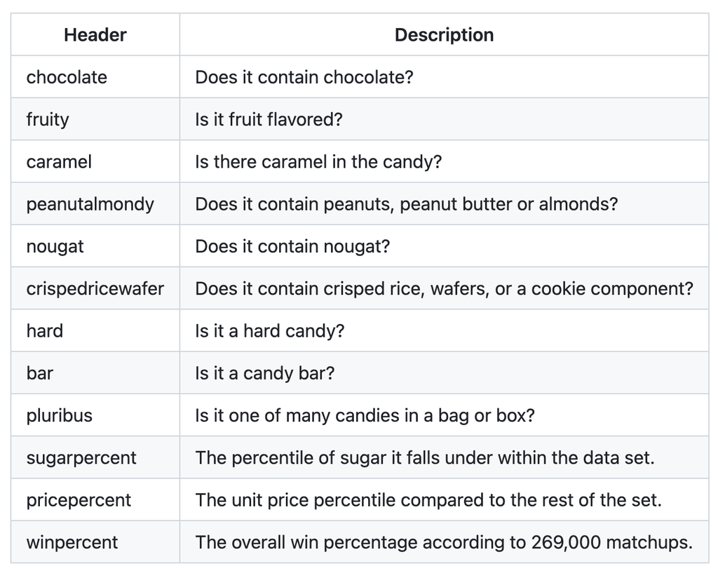

For binary variables 1 = yes and 0 = no

# Looking at your data

Once you have read-in a data set, you can click on it in the “environment” tab and a new window will appear. You can also check your data in script. R users commonly refer to a read-in data set as a “data.frame” (hence the use of df to commonly label data.frames). You can use the `head()` function to observe the first few rows of your data.frame and the `str()` function to observe variable types contained in your data.frame.

```r
# Observe the first few rows of your data.frame
head(candy_df)
```

```
##   competitorname chocolate fruity caramel peanutyalmondy nougat
## 1      100 Grand         1      0       1              0      0
## 2   3 Musketeers         1      0       0              0      1
## 3       One dime         0      0       0              0      0
## 4    One quarter         0      0       0              0      0
## 5      Air Heads         0      1       0              0      0
## 6     Almond Joy         1      0       0              1      0
##   crispedricewafer hard bar pluribus sugarpercent pricepercent winpercent
## 1                1    0   1        0        0.732        0.860   66.97173
## 2                0    0   1        0        0.604        0.511   67.60294
## 3                0    0   0        0        0.011        0.116   32.26109
## 4                0    0   0        0        0.011        0.511   46.11650
## 5                0    0   0        0        0.906        0.511   52.34146
## 6                0    0   1        0        0.465        0.767   50.34755
```

```r
# Observe the structure of your data.frame
str(candy_df)
```

```
## 'data.frame':    85 obs. of  13 variables:
##  $ competitorname  : chr  "100 Grand" "3 Musketeers" "One dime" "One quarter" ...
##  $ chocolate       : int  1 1 0 0 0 1 1 0 0 0 ...
##  $ fruity          : int  0 0 0 0 1 0 0 0 0 1 ...
##  $ caramel         : int  1 0 0 0 0 0 1 0 0 1 ...
##  $ peanutyalmondy  : int  0 0 0 0 0 1 1 1 0 0 ...
##  $ nougat          : int  0 1 0 0 0 0 1 0 0 0 ...
##  $ crispedricewafer: int  1 0 0 0 0 0 0 0 0 0 ...
##  $ hard            : int  0 0 0 0 0 0 0 0 0 0 ...
##  $ bar             : int  1 1 0 0 0 1 1 0 0 0 ...
##  $ pluribus        : int  0 0 0 0 0 0 0 1 1 0 ...
##  $ sugarpercent    : num  0.732 0.604 0.011 0.011 0.906 ...
##  $ pricepercent    : num  0.86 0.511 0.116 0.511 0.511 ...
##  $ winpercent      : num  67 67.6 32.3 46.1 52.3 ...
```

# Manipulating your data

We can see from the `str()` function that the data read-in the binary variables as integers, but we actually know they are factors. We can adjust this using the `mutate()` function which comes from the [dplyr](https://dplyr.tidyverse.org/index.html) package.

```r
# Turn one integer variable into a factor
candy_df <- candy_df |>
  mutate(chocolate_factor = as.factor(chocolate))

# Observe the structure of your data.frame
str(candy_df)
```

```
## 'data.frame':    85 obs. of  14 variables:
##  $ competitorname  : chr  "100 Grand" "3 Musketeers" "One dime" "One quarter" ...
##  $ chocolate       : int  1 1 0 0 0 1 1 0 0 0 ...
##  $ fruity          : int  0 0 0 0 1 0 0 0 0 1 ...
##  $ caramel         : int  1 0 0 0 0 0 1 0 0 1 ...
##  $ peanutyalmondy  : int  0 0 0 0 0 1 1 1 0 0 ...
##  $ nougat          : int  0 1 0 0 0 0 1 0 0 0 ...
##  $ crispedricewafer: int  1 0 0 0 0 0 0 0 0 0 ...
##  $ hard            : int  0 0 0 0 0 0 0 0 0 0 ...
##  $ bar             : int  1 1 0 0 0 1 1 0 0 0 ...
##  $ pluribus        : int  0 0 0 0 0 0 0 1 1 0 ...
##  $ sugarpercent    : num  0.732 0.604 0.011 0.011 0.906 ...
##  $ pricepercent    : num  0.86 0.511 0.116 0.511 0.511 ...
##  $ winpercent      : num  67 67.6 32.3 46.1 52.3 ...
##  $ chocolate_factor: Factor w/ 2 levels "0","1": 2 2 1 1 1 2 2 1 1 1 ...
```

But maybe we aren’t all that interested in each of these candy attributes separately. Instead, maybe we think that having more candy attributes might be related to some of our other variables, such as how winning the candy was. Or maybe we think that candy that contains chocolate will have higher average win percentages than candy without chocolate. We can use tidyverse functions to prepare the data to ask these questions.

First, lets create a variable that adds all the possible candy attributes together for each candy. We will use the `rowwise()` and `mutate()` functions which comes from the dplyr package.

```r
# Sum candy attributes
candy_df <- candy_df |>
  ## rowwise() tells the data.frame to calculate by rows
  rowwise() |>
  ## mutate() allows you to flexibly manipulate data
  mutate(candyattributesum = sum(across(2:10))) |>
  ## as_data_frame() returns the data from rowwise to data.frame format
  as.data.frame()

# Observe new variable
## select(), also from dplyr, let's you choose particular variables
head(candy_df |> select(competitorname, candyattributesum))
```

```
##   competitorname candyattributesum
## 1      100 Grand                 4
## 2   3 Musketeers                 3
## 3       One dime                 0
## 4    One quarter                 0
## 5      Air Heads                 1
## 6     Almond Joy                 3
```

Great! We see we created a new variable that sums candy attributes. What if we want to create winning averages based on candy features? For simplicity, let’s look at chocolate vs fruity candies. I am going to create a new data.frame that focuses on those two candy types using `filter()` from dplyr.

```r
# Create average winning scores
candy_chocolatevsfruity_df <- candy_df |>
  # This tells the data.frame to keep candy labeled as chocolate or fruity
  filter(chocolate == 1 | fruity == 1) |>
  # Creating a new variable to label the groups
  mutate(type = ifelse(chocolate == 1, 1,
                       ifelse(fruity == 1, 2, NA))) |>
  select(competitorname, type, winpercent)

# Observe resulting data.frame
head(candy_chocolatevsfruity_df)
```

```
##       competitorname type winpercent
## 1          100 Grand    1   66.97173
## 2       3 Musketeers    1   67.60294
## 3          Air Heads    2   52.34146
## 4         Almond Joy    1   50.34755
## 5          Baby Ruth    1   56.91455
## 6 Caramel Apple Pops    2   34.51768
```

Next, I am going to use `group_by()` from dplyr to find the average win percent for chocolate vs fruity candy.

```r
candy_chocolatevsfruity_df <- candy_chocolatevsfruity_df |>
  group_by(type) |>
  mutate(averagewinpercent = mean(winpercent)) |>
  select(competitorname, type, winpercent, averagewinpercent)

# Observe resulting data.frame
head(candy_chocolatevsfruity_df)
```

```
## # A tibble: 6 × 4
## # Groups:   type [2]
##   competitorname      type winpercent averagewinpercent
##   <chr>              <dbl>      <dbl>             <dbl>
## 1 100 Grand              1       67.0              60.9
## 2 3 Musketeers           1       67.6              60.9
## 3 Air Heads              2       52.3              44.0
## 4 Almond Joy             1       50.3              60.9
## 5 Baby Ruth              1       56.9              60.9
## 6 Caramel Apple Pops     2       34.5              44.0
```

# Analyzing and visualizing your data

We now have two data.frames ready for different analyses. Let’s start by checking our descriptive statistics. I am going to use the `describe()` function from the psych package.

```r
psych::describe(candy_df |> select(11:14))
```

```
##                   vars  n  mean    sd median trimmed   mad   min   max range
## sugarpercent         1 85  0.48  0.28   0.47    0.48  0.36  0.01  0.99  0.98
## pricepercent         2 85  0.47  0.29   0.47    0.46  0.31  0.01  0.98  0.97
## winpercent           3 85 50.32 14.71  47.83   49.80 14.56 22.45 84.18 61.73
## chocolate_factor*    4 85  1.44  0.50   1.00    1.42  0.00  1.00  2.00  1.00
##                   skew kurtosis   se
## sugarpercent      0.09    -1.18 0.03
## pricepercent      0.13    -1.20 0.03
## winpercent        0.32    -0.67 1.60
## chocolate_factor* 0.26    -1.96 0.05
```

We can also get summaries about our chocolate vs fruity groupings. I am using the `group_by()` and `summarise()` functions from dplyr

```r
candy_chocolatevsfruity_df |>
  group_by(type) |>
  summarise(n())
```

```
## # A tibble: 2 × 2
##    type `n()`
##   <dbl> <int>
## 1     1    37
## 2     2    37
```

Now let’s check the correlations between our variables. I am going to use the `rcorr()` function from Hmisc.

```r
rcorr(as.matrix(candy_df |> select(11:14), type = "pearson"))
```

```
##                  sugarpercent pricepercent winpercent chocolate_factor
## sugarpercent             1.00         0.33       0.23             0.10
## pricepercent             0.33         1.00       0.35             0.50
## winpercent               0.23         0.35       1.00             0.64
## chocolate_factor         0.10         0.50       0.64             1.00
##
## n= 85
##
##
## P
##                  sugarpercent pricepercent winpercent chocolate_factor
## sugarpercent                  0.0021       0.0349     0.3427
## pricepercent     0.0021                    0.0012     0.0000
## winpercent       0.0349       0.0012                  0.0000
## chocolate_factor 0.3427       0.0000       0.0000
```

Our correlations look pretty decent! But it is always preferable to visualize correlations. There are a couple way you can do this, but first I will show you `ggpairs()` from the GGally package as it is my favorite way to present descriptive data.

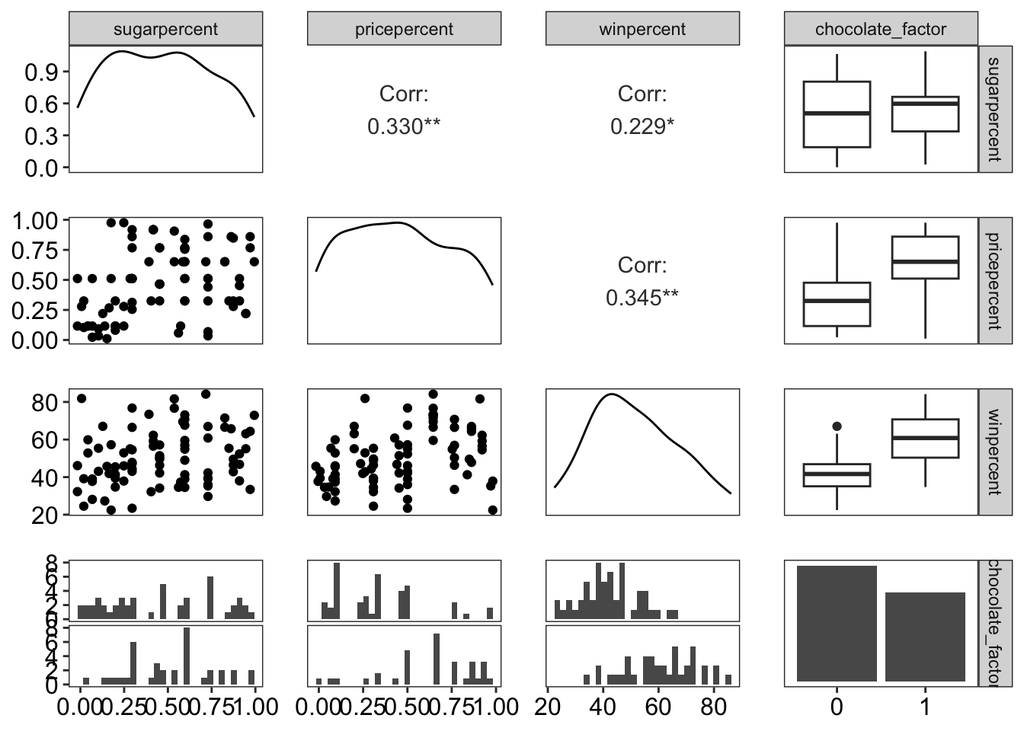

```r
ggpairs(candy_df |> select(11:14), progress = FALSE)
```

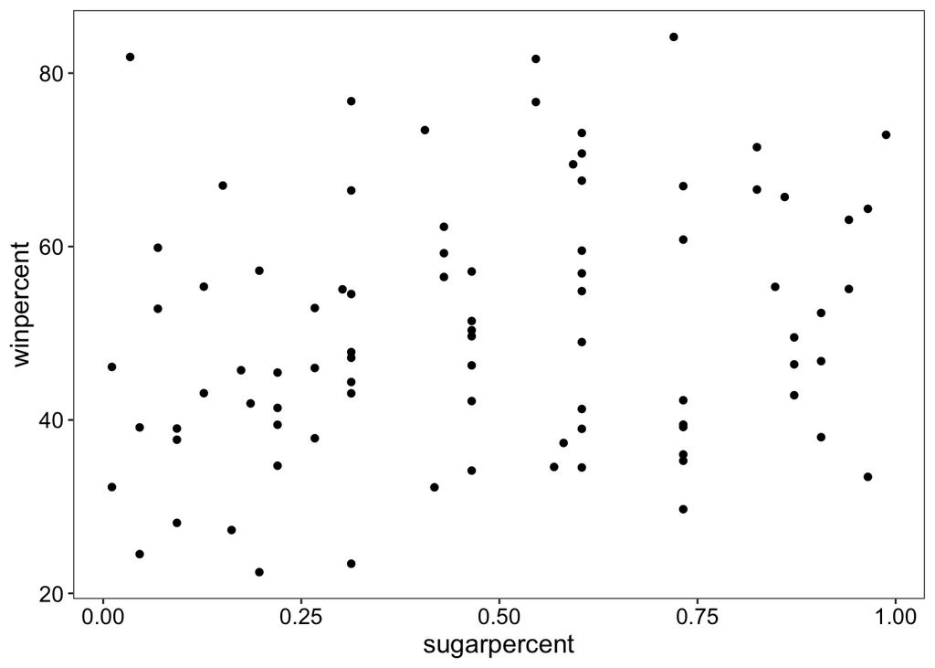

```r
ggplot(candy_df, aes(sugarpercent, winpercent)) +
  geom_point()
```

Maybe now you want to see the line of best fit for the relation.

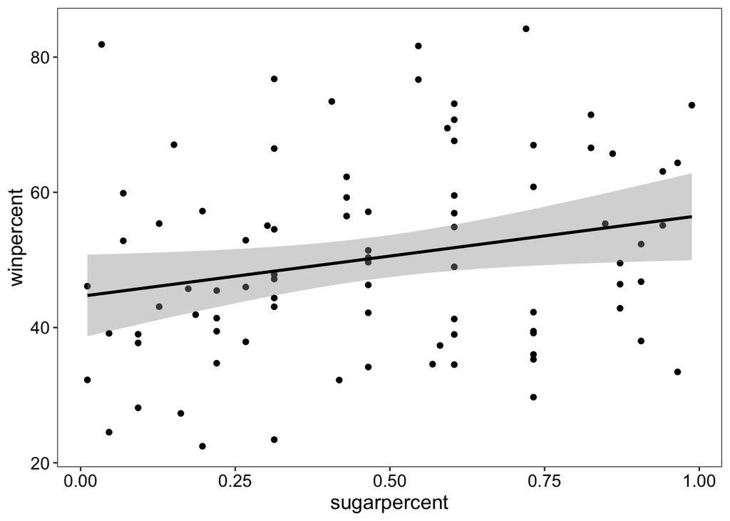

```r
ggplot(candy_df, aes(sugarpercent, winpercent)) +
  geom_point() +
  geom_smooth(method = "lm", color = "black")
```

Maybe you’re curious if this relation varies by number of candy attributes.

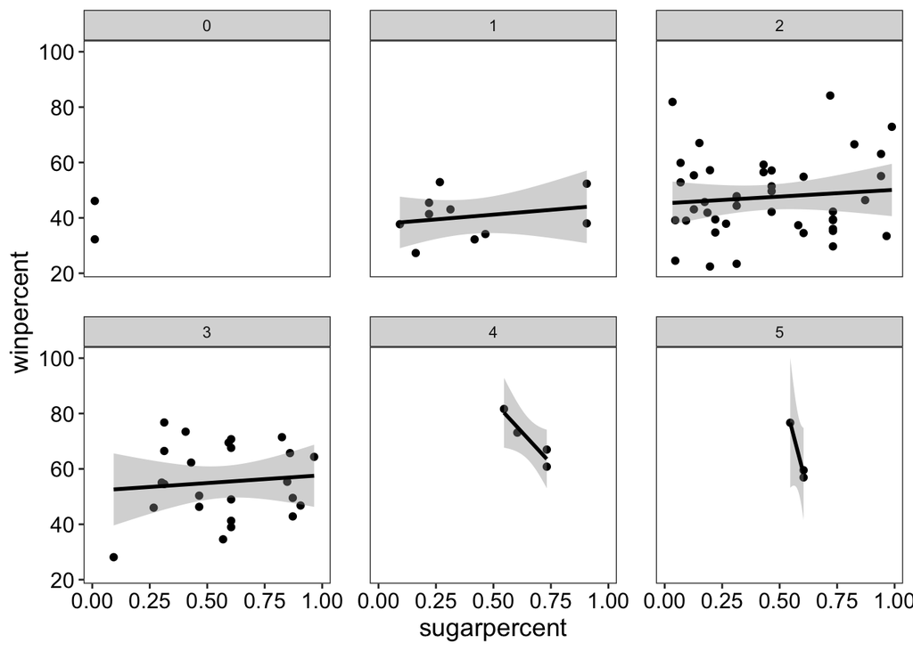

```r
ggplot(candy_df, aes(sugarpercent, winpercent)) +
  geom_point() +
  geom_smooth(method = "lm", color = "black") +
  facet_wrap(~candyattributesum)
```

We can run a linear model to see if both sugar percent and candy attributes contribute to win percent.

```r
lm <- with(candy_df, lm(winpercent ~ sugarpercent + candyattributesum))

summary(lm)
```

```
##
## Call:
## lm(formula = winpercent ~ sugarpercent + candyattributesum)
##
## Residuals:
##     Min      1Q  Median      3Q     Max
## -25.038  -9.301  -1.023   9.017  35.752
##
## Coefficients:
##                   Estimate Std. Error t value Pr(>|t|)
## (Intercept)         32.401      3.999   8.101 4.40e-12 ***
## sugarpercent         4.608      5.337   0.863     0.39
## candyattributesum    6.779      1.582   4.285 4.95e-05 ***
## ---
## Signif. codes:  0 '***' 0.001 '**' 0.01 '*' 0.05 '.' 0.1 ' ' 1
##
## Residual standard error: 13.1 on 82 degrees of freedom
## Multiple R-squared:  0.2258, Adjusted R-squared:  0.2069
## F-statistic: 11.96 on 2 and 82 DF,  p-value: 2.769e-05
```

Maybe now you want to know more about our chocolate vs fruity candy question. We can run a t-test to see if chocolate or fruity candy has higher win percents.

```r
with(candy_chocolatevsfruity_df, t.test(winpercent~type))
```

```
##
##  Welch Two Sample t-test
##
## data:  winpercent by type
## t = 6.2485, df = 69.013, p-value = 2.968e-08
## alternative hypothesis: true difference in means between group 1 and group 2 is not equal to 0
## 95 percent confidence interval:
##  11.52703 22.33940
## sample estimates:
## mean in group 1 mean in group 2
##        60.92153        43.98831
```

We can make a bar graph to visualize this difference. I am going to use the Rmisc package to calculate error bars for the figure.

```r
library(Rmisc)
candy_chocolatevsfruitysummary_df <- summarySEwithin(candy_chocolatevsfruity_df,
                           measurevar="winpercent",
                           withinvars=c("type"),
                           #idvar="type",
                           na.rm=TRUE, conf.interval=.95)
```

```
## Automatically converting the following non-factors to factors: type
```

```r
detach("package:Rmisc", unload=TRUE)
```

Now I am going to plot the bar graph. When I add color to a graph, I like to use the viridis package as it is colorblind friendly.

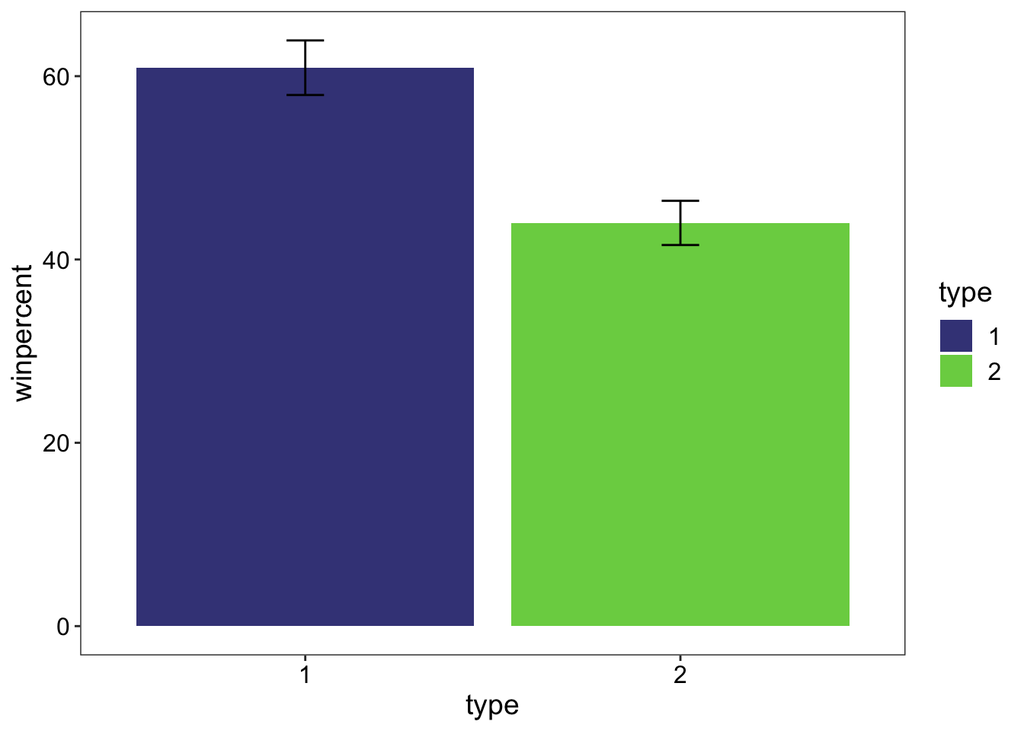

```r
ggplot(candy_chocolatevsfruitysummary_df, aes(type, winpercent, fill = type)) +
  geom_bar(stat = "summary", fun = "mean") +
  geom_errorbar(position = position_dodge(.9), width = .1,
                aes(ymin=winpercent-se,
                    ymax=winpercent+se)) +
  scale_fill_viridis_d(begin = .2, end = .8)
```

Maybe we decide this is the story we really want to tell: the superiority of chocolate over fruity candies. We can dress up this figure to make it publication ready by adding more informative labels.

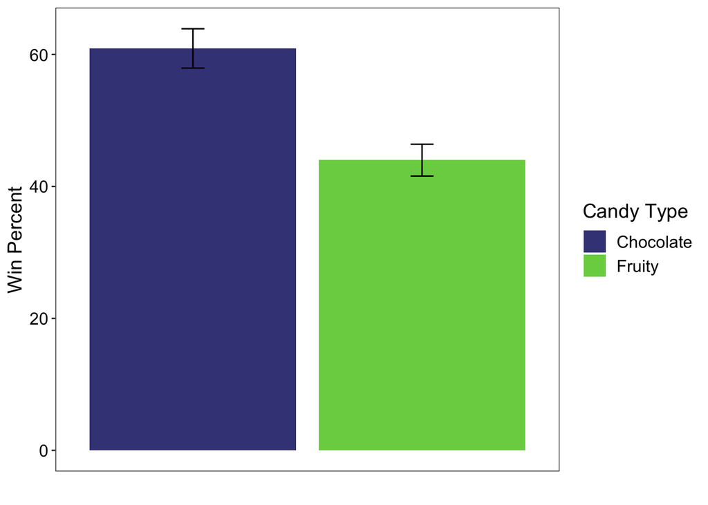

```r
candy_figure <- ggplot(candy_chocolatevsfruitysummary_df,
                       aes(type, winpercent, fill = type)) +
  geom_bar(stat = "summary", fun = "mean") +
  geom_errorbar(position = position_dodge(.9), width = .1,
                aes(ymin=winpercent-se,
                    ymax=winpercent+se)) +
  scale_fill_viridis_d(begin = .2, end = .8, labels = c("Chocolate", "Fruity")) +
  labs(x = "", y = "Win Percent", fill = "Candy Type") +
  theme(axis.text.x = element_blank(),
        axis.ticks.x = element_blank())

candy_figure
```

Now we can export this figure for publication!

```r
out_path <- file.path(home_path,"/tutorial_output/candy_figure.png", fsep ="")
ggsave(out_path, plot = candy_figure, width = 6, height = 4, dpi = 300)
```

# Summary

This was a very speedy run through of some of the things you can do with R. However, often issues with data, analyses and visualization end up being much more complicated than what we did today. We can look at more advanced topics on a case-by-case basis or in future tutorials which could cover topics like manipulating and analyzing longitudinal data, visualizing interactions, etc.